# Chapter 6

Kalle Karvonen

2023-12-11

# Chapter 6: Analysis of longitudinal data

```r
# Data used is based on the data of Kimmo Vehkalahti from the following URL
#https://raw.githubusercontent.com/KimmoVehkalahti/MABS/master/Examples/data/BPRS.txt
#https://raw.githubusercontent.com/KimmoVehkalahti/MABS/master/Examples/data/rats.txt

ratsl <-read.csv("C:/Users/Kalka/OneDrive/Desktop/Random/School/Open_Data/IODS-project/data/ratsl.csv")
```

```r
# Loading in the data might lose categorical variables set as factors  so lets put them again

ratsl$ID<- as.factor(ratsl$ID)
ratsl$Group<-as.factor(ratsl$Group)
head(ratsl)
```

```
##   ID Group Weight Time
## 1  1     1    240    1
## 2  2     1    225    1
## 3  3     1    245    1
## 4  4     1    260    1
## 5  5     1    255    1
## 6  6     1    260    1
```

- lets follow the course book chapter 8 analysis but use the rat dataset instead of BPRSL
- The rat dataset describes the weight of 16 rats over 9 weeks of observation, The rats were assigned different diets out of 3 options. Weight is the weight of a rat in grams and time is in days

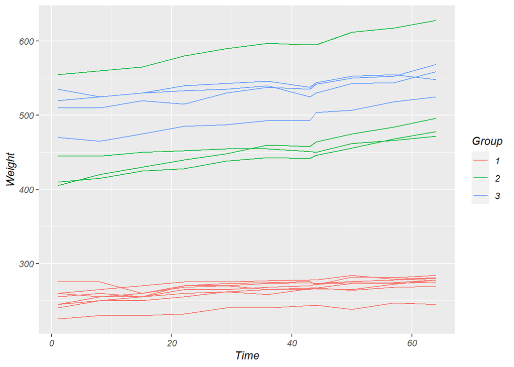

```r
# Initialising some packages that might be needed
library(ggplot2)
library(readr)
library(dplyr)
library(tidyr)
# Draw the plots
ggplot(ratsl)+geom_line(aes(x=Time,y=Weight,group=ID,color=Group))
```

- a slight increase in weight can be seen in the groups, vut initial weight is much lower in group 1. Largest weight gain seems to be in group 2

- lets do a standardization and see if it changes anything in our graph

```r
# based on Ex6 code
ratsl_std <- ratsl %>%
  group_by(Group) %>%
  mutate(stdweight = (Weight - mean(Weight))/sd(Weight)) %>%
  ungroup()

# Glimpse the data
glimpse(ratsl_std)
```

```
## Rows: 176
## Columns: 5
## $ ID        <fct> 1, 2, 3, 4, 5, 6, 7, 8, 9, 10, 11, 12, 13, 14, 15, 16, 1, 2,…
## $ Group     <fct> 1, 1, 1, 1, 1, 1, 1, 1, 2, 2, 2, 2, 3, 3, 3, 3, 1, 1, 1, 1, …
## $ Weight    <int> 240, 225, 245, 260, 255, 260, 275, 245, 410, 405, 445, 555, …
## $ Time      <int> 1, 1, 1, 1, 1, 1, 1, 1, 1, 1, 1, 1, 1, 1, 1, 1, 15, 15, 15, …
## $ stdweight <dbl> -1.7326345, -2.8285030, -1.3673450, -0.2714765, -0.6367660, …
```

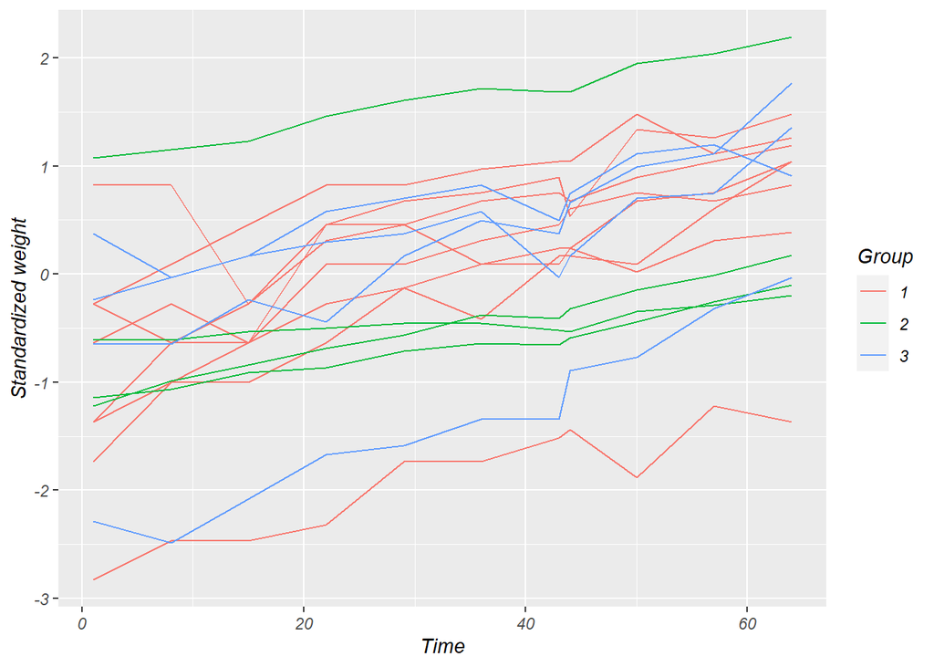

```r
# Plot again with the new data
ggplot(ratsl_std)+geom_line(aes(x=Time,y=stdweight,group=ID,color=Group))+
  labs(y = "Standardized weight")
```

- Now we can see the pattern of weight growth better which was hard to see previously due to high variation of starting weight.

- Lets plot

```r
# Summary data with mean and standard error of ratsl by treatment and week
# Function from the ex 6
se <- function(x,n) { sd(x)/sqrt(n) }

ratsl_s <- ratsl %>%
  group_by(Group, Time) %>%
  summarise(mean = mean(Weight), se = se(Weight, length(Weight)) ) %>%
  ungroup()
glimpse(ratsl_s)
```

```
## Rows: 33
## Columns: 4
## $ Group <fct> 1, 1, 1, 1, 1, 1, 1, 1, 1, 1, 1, 2, 2, 2, 2, 2, 2, 2, 2, 2, 2, 2…
## $ Time  <int> 1, 8, 15, 22, 29, 36, 43, 44, 50, 57, 64, 1, 8, 15, 22, 29, 36, …
## $ mean  <dbl> 250.625, 255.000, 254.375, 261.875, 264.625, 265.000, 267.375, 2…
## $ se    <dbl> 5.381640, 4.629100, 4.057346, 4.808614, 3.909409, 4.166190, 3.87…
```

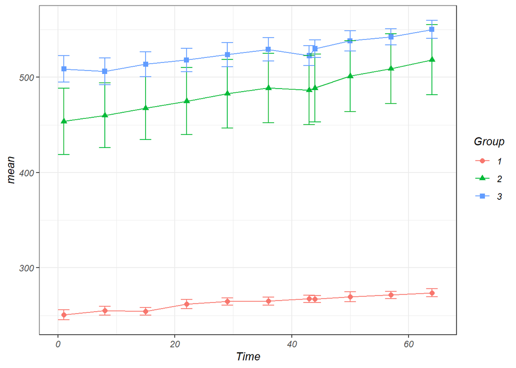

```r
ggplot(ratsl_s, aes(x = Time, y = mean, color = Group)) +
  geom_line() +
  geom_point(aes(shape=Group), size=2) +
  theme_bw() +
  geom_errorbar(aes(ymin = mean-se, ymax = mean+se), width=2)
```

- Variation in group 1 is smaller than the others especially group 2 has a large variation which might be due to an outlier group.

- lets do a boxplot to see any potential outliers

```r
ratsl_bp <- ratsl %>%
  group_by(Group, ID) %>%
  summarise(mean=mean(Weight) ) %>%
  ungroup()
```

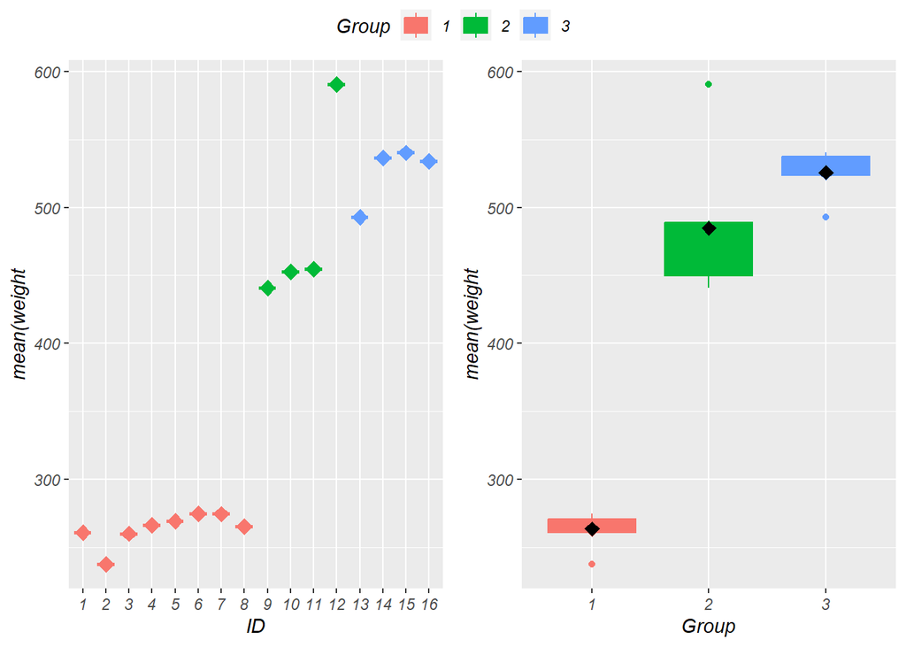

```r
library(ggplot2)
library(ggpubr)
box1 <-ggplot(ratsl_bp, aes(x = ID, y = mean,color=Group,fill=Group)) +
  geom_boxplot() +
  stat_summary(fun = "mean", geom = "point", shape=23, size=3) +
  scale_y_continuous(name = "mean(weight")

box2 <-ggplot(ratsl_bp, aes(x = Group, y = mean, color=Group,fill=Group)) +
  geom_boxplot() +
  stat_summary(fun = "mean", geom = "point", shape=23, size=3,fill="black") +
  scale_y_continuous(name = "mean(weight")

ggarrange(box1,box2, common.legend=T)
```

- Based on this one could say that rats 2 12 and 13 are outliers when compared to their groups.

- Filtering the outliers and trying again

```r
ratsl_fltr <- ratsl %>%
  filter(ID != 2 & ID != 12 & ID != 13) %>%
  group_by(Group, ID) %>%
  summarise(mean=mean(Weight) ) %>%
  ungroup()
```

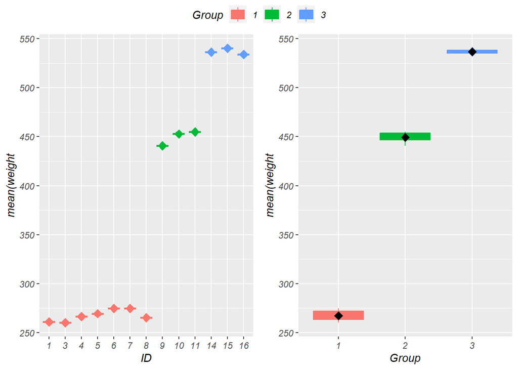

```r
library(ggplot2)
library(ggpubr)
box1 <-ggplot(ratsl_fltr, aes(x = ID, y = mean,color=Group,fill=Group)) +
  geom_boxplot() +
  stat_summary(fun = "mean", geom = "point", shape=23, size=3) +
  scale_y_continuous(name = "mean(weight")

box2 <-ggplot(ratsl_fltr, aes(x = Group, y = mean, color=Group,fill=Group)) +
  geom_boxplot() +
  stat_summary(fun = "mean", geom = "point", shape=23, size=3,fill="black") +
  scale_y_continuous(name = "mean(weight")

ggarrange(box1,box2, common.legend=T)
```

- Data seems to be now more uniform - Lastly lets fit a linear model and analyze it

```r
# We need to filter the base data
ratsl_fltr <- ratsl %>%
  filter(ID != 2 & ID != 12 & ID != 13)

ratsl_lm <- lm(data=ratsl_fltr,Weight~Time+Group)

summary(ratsl_lm)
```

```
##
## Call:
## lm(formula = Weight ~ Time + Group, data = ratsl_fltr)
##
## Residuals:
##      Min       1Q   Median       3Q      Max
## -26.9941  -5.7803  -0.0744   5.6949  30.2068
##
## Coefficients:
##              Estimate Std. Error t value Pr(>|t|)
## (Intercept) 249.44461    1.69082  147.53   <2e-16 ***
## Time          0.53649    0.03955   13.57   <2e-16 ***
## Group2      182.01299    1.91405   95.09   <2e-16 ***
## Group3      269.31602    1.91405  140.71   <2e-16 ***
## ---
## Signif. codes:  0 '***' 0.001 '**' 0.01 '*' 0.05 '.' 0.1 ' ' 1
##
## Residual standard error: 9.199 on 139 degrees of freedom
## Multiple R-squared:  0.994,  Adjusted R-squared:  0.9939
## F-statistic:  7685 on 3 and 139 DF,  p-value: < 2.2e-16
```

```r
anova(ratsl_lm)
```

```
## Analysis of Variance Table
##
## Response: Weight
##            Df  Sum Sq Mean Sq  F value    Pr(>F)
## Time        1   15576   15576   184.05 < 2.2e-16 ***
## Group       2 1935537  967769 11435.47 < 2.2e-16 ***
## Residuals 139   11763      85
## ---
## Signif. codes:  0 '***' 0.001 '**' 0.01 '*' 0.05 '.' 0.1 ' ' 1
```

- there seems to be a very low p-value on all groups so the difference is significant -R squared of 0.994 says that 99.4% of our variation can be attributed to our variables

### Chapter 6 part 2 (BPRS data analysis)

-The BPRS data consists of brief psychiatric rating scale values for 40 men before and after treatment on different time frames on two different treatment groups

```r
BPRSL <-read.csv("C:/Users/Kalka/OneDrive/Desktop/Random/School/Open_Data/IODS-project/data/BPRSL.csv")
BPRSL<- as.data.frame(BPRSL)
BPRSL$subject <- as.factor(BPRSL$subject)
BPRSL$treatment <- as.factor(BPRSL$treatment)

summary(BPRSL)
```

```
##  treatment    subject         bprs            week
##  1:180     1      : 18   Min.   :18.00   Min.   :0
##  2:180     2      : 18   1st Qu.:27.00   1st Qu.:2
##            3      : 18   Median :35.00   Median :4
##            4      : 18   Mean   :37.66   Mean   :4
##            5      : 18   3rd Qu.:43.00   3rd Qu.:6
##            6      : 18   Max.   :95.00   Max.   :8
##            (Other):252
```

```r
str(BPRSL)
```

```
## 'data.frame':    360 obs. of  4 variables:
##  $ treatment: Factor w/ 2 levels "1","2": 1 1 1 1 1 1 1 1 1 1 ...
##  $ subject  : Factor w/ 20 levels "1","2","3","4",..: 1 2 3 4 5 6 7 8 9 10 ...
##  $ bprs     : int  42 58 54 55 72 48 71 30 41 57 ...
##  $ week     : int  0 0 0 0 0 0 0 0 0 0 ...
```

- Treatment is a variable with either 1 or 2 which shows the treatment group
- subject is an identifier for the individual
- bprs is the brief psychiatric rating scale
- week is the time of data collection

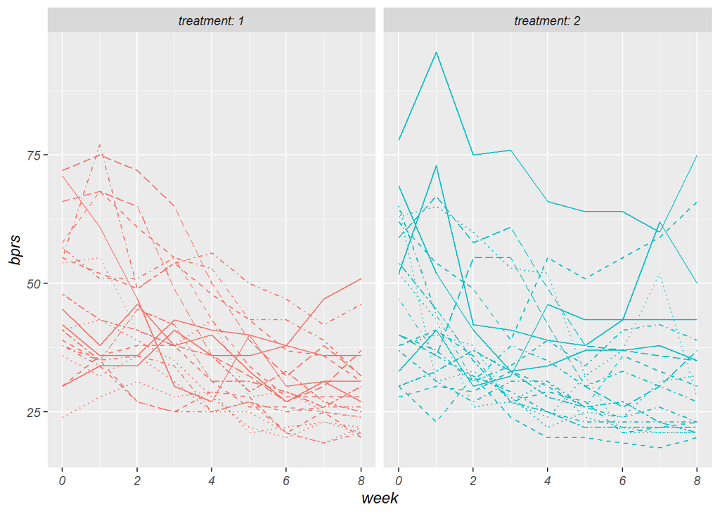

```r
ggplot(BPRSL, aes(x = week, y = bprs, linetype = subject, color=treatment)) +
  geom_line() +
  scale_linetype_manual(values = rep(1:10, times=4)) +
  facet_grid(. ~ treatment, labeller = label_both) +
  theme(legend.position = "none") +
  scale_y_continuous(limits = c(min(BPRSL$bprs), max(BPRSL$bprs)))
```

- both groups have a downwards trend although some Ids show variability

Fitting a linear model

```r
# basic linear model
BPRS_lm <- lm(bprs ~ week + treatment, data = BPRSL)
summary(BPRS_lm)
```

```
##
## Call:
## lm(formula = bprs ~ week + treatment, data = BPRSL)
##
## Residuals:
##     Min      1Q  Median      3Q     Max
## -22.454  -8.965  -3.196   7.002  50.244
##
## Coefficients:
##             Estimate Std. Error t value Pr(>|t|)
## (Intercept)  46.4539     1.3670  33.982   <2e-16 ***
## week         -2.2704     0.2524  -8.995   <2e-16 ***
## treatment2    0.5722     1.3034   0.439    0.661
## ---
## Signif. codes:  0 '***' 0.001 '**' 0.01 '*' 0.05 '.' 0.1 ' ' 1
##
## Residual standard error: 12.37 on 357 degrees of freedom
## Multiple R-squared:  0.1851, Adjusted R-squared:  0.1806
## F-statistic: 40.55 on 2 and 357 DF,  p-value: < 2.2e-16
```

- Based on this there would seem to be no difference between treatments and both treatments seem to reduce the symtoms(bprs score)
- how about other model

```r
library(lme4)
library(Matrix)
```

```r
# random intercept model

BPRS_ref <- lmer(bprs ~ week + treatment + (1 | subject), data = BPRSL, REML = FALSE)
summary(BPRS_ref)
```

```
## Linear mixed model fit by maximum likelihood  ['lmerMod']
## Formula: bprs ~ week + treatment + (1 | subject)
##    Data: BPRSL
##
##      AIC      BIC   logLik deviance df.resid
##   2748.7   2768.1  -1369.4   2738.7      355
##
## Scaled residuals:
##     Min      1Q  Median      3Q     Max
## -3.0481 -0.6749 -0.1361  0.4813  3.4855
##
## Random effects:
##  Groups   Name        Variance Std.Dev.
##  subject  (Intercept)  47.41    6.885
##  Residual             104.21   10.208
## Number of obs: 360, groups:  subject, 20
##
## Fixed effects:
##             Estimate Std. Error t value
## (Intercept)  46.4539     1.9090  24.334
## week         -2.2704     0.2084 -10.896
## treatment2    0.5722     1.0761   0.532
##
## Correlation of Fixed Effects:
##            (Intr) week
## week       -0.437
## treatment2 -0.282  0.000
```

```r
#random intercept and slope model
BPRS_ref2 <- lmer(bprs ~ week + treatment + (week | subject), data = BPRSL, REML = FALSE)
summary(BPRS_ref2)
```

```
## Linear mixed model fit by maximum likelihood  ['lmerMod']
## Formula: bprs ~ week + treatment + (week | subject)
##    Data: BPRSL
##
##      AIC      BIC   logLik deviance df.resid
##   2745.4   2772.6  -1365.7   2731.4      353
##
## Scaled residuals:
##     Min      1Q  Median      3Q     Max
## -2.8919 -0.6194 -0.0691  0.5531  3.7976
##
## Random effects:
##  Groups   Name        Variance Std.Dev. Corr
##  subject  (Intercept) 64.8222  8.0512
##           week         0.9609  0.9802   -0.51
##  Residual             97.4305  9.8707
## Number of obs: 360, groups:  subject, 20
##
## Fixed effects:
##             Estimate Std. Error t value
## (Intercept)  46.4539     2.1052  22.066
## week         -2.2704     0.2977  -7.626
## treatment2    0.5722     1.0405   0.550
##
## Correlation of Fixed Effects:
##            (Intr) week
## week       -0.582
## treatment2 -0.247  0.000
```

```r
anova(BPRS_ref, BPRS_lm)
```

```
## Data: BPRSL
## Models:
## BPRS_lm: bprs ~ week + treatment
## BPRS_ref: bprs ~ week + treatment + (1 | subject)
##          npar    AIC    BIC  logLik deviance  Chisq Df Pr(>Chisq)
## BPRS_lm     4 2837.3 2852.9 -1414.7   2829.3
## BPRS_ref    5 2748.7 2768.1 -1369.4   2738.7 90.624  1  < 2.2e-16 ***
## ---
## Signif. codes:  0 '***' 0.001 '**' 0.01 '*' 0.05 '.' 0.1 ' ' 1
```

```r
anova(BPRS_ref2,BPRS_ref)
```

```
## Data: BPRSL
## Models:
## BPRS_ref: bprs ~ week + treatment + (1 | subject)
## BPRS_ref2: bprs ~ week + treatment + (week | subject)
##           npar    AIC    BIC  logLik deviance  Chisq Df Pr(>Chisq)
## BPRS_ref     5 2748.7 2768.1 -1369.4   2738.7
## BPRS_ref2    7 2745.4 2772.6 -1365.7   2731.4 7.2721  2    0.02636 *
## ---
## Signif. codes:  0 '***' 0.001 '**' 0.01 '*' 0.05 '.' 0.1 ' ' 1
```

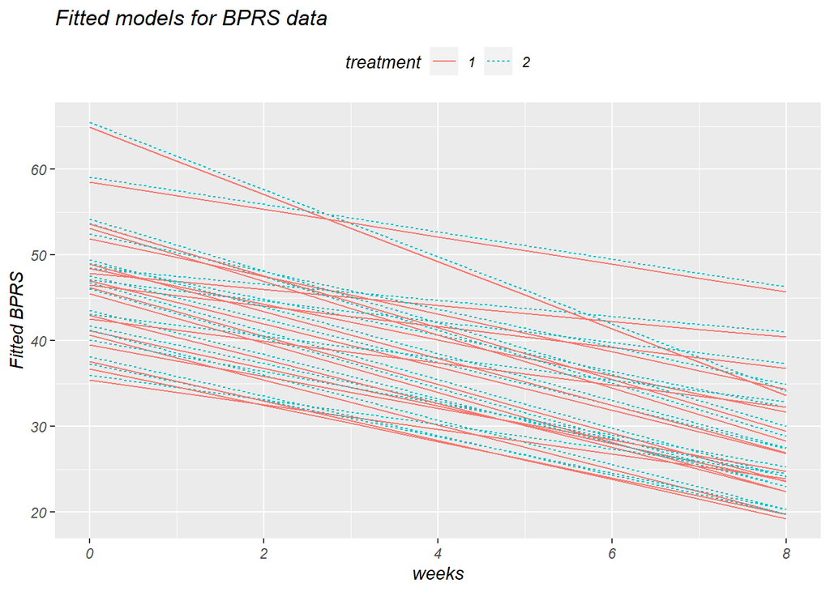

```r
#Lets plot our model
Fitted <- fitted(BPRS_ref2)
BPRSL$Fitted <- Fitted

ggplot(BPRSL, aes(x = week, y = Fitted, group = interaction(treatment, subject))) +
  geom_line(aes(linetype = treatment, colour=treatment)) +
  scale_x_continuous(name = "weeks")+
  scale_y_continuous(name = "Fitted BPRS") +
  theme(legend.position = "top")  +
  ggtitle("Fitted models for BPRS data")
```

- From this it would seem that both treatments reduce the symptoms and neither seems to be better than the other.